# Video Games project: R beadandó - Pálos Péter

Beadandóm alapjául a https://www.kaggle.com/ oldalról választottam egy nagyon izgalmasnak tűnő adatbázist, mely videójátékokról származó adatokat tartalmaz.

forrás: [Video Game Sales with Ratings](https://www.kaggle.com/rush4ratio/video-game-sales-with-ratings)

Az elemzéshez használt csomagok:

```r
library(dplyr)
library(ggplot2)
library(tidyr)
library(lubridate)
```

### Ismerkedés az adattáblával

Miután beolvastam a nyers adattáblát

```r
dat <- read.csv("Video_Games_Sales.csv", header=TRUE, na.strings=c("", " ", "NA", "N/A"))
```

kicsit “körbe szaglászom” azt:

```r
glimpse(dat)
```

```
## Rows: 16,719
## Columns: 16
## $ Name            <chr> "Wii Sports", "Super Mario Bros.", "Mario Kart Wii"...
## $ Platform        <chr> "Wii", "NES", "Wii", "Wii", "GB", "GB", "DS", "Wii"...
## $ Year_of_Release <int> 2006, 1985, 2008, 2009, 1996, 1989, 2006, 2006, 200...
## $ Genre           <chr> "Sports", "Platform", "Racing", "Sports", "Role-Pla...
## $ Publisher       <chr> "Nintendo", "Nintendo", "Nintendo", "Nintendo", "Ni...
## $ NA_Sales        <dbl> 41.36, 29.08, 15.68, 15.61, 11.27, 23.20, 11.28, 13...
## $ EU_Sales        <dbl> 28.96, 3.58, 12.76, 10.93, 8.89, 2.26, 9.14, 9.18, ...
## $ JP_Sales        <dbl> 3.77, 6.81, 3.79, 3.28, 10.22, 4.22, 6.50, 2.93, 4....
## $ Other_Sales     <dbl> 8.45, 0.77, 3.29, 2.95, 1.00, 0.58, 2.88, 2.84, 2.2...
## $ Global_Sales    <dbl> 82.53, 40.24, 35.52, 32.77, 31.37, 30.26, 29.80, 28...
## $ Critic_Score    <int> 76, NA, 82, 80, NA, NA, 89, 58, 87, NA, NA, 91, NA,...
## $ Critic_Count    <int> 51, NA, 73, 73, NA, NA, 65, 41, 80, NA, NA, 64, NA,...
## $ User_Score      <chr> "8", NA, "8.3", "8", NA, NA, "8.5", "6.6", "8.4", N...
## $ User_Count      <int> 322, NA, 709, 192, NA, NA, 431, 129, 594, NA, NA, 4...
## $ Developer       <chr> "Nintendo", NA, "Nintendo", "Nintendo", NA, NA, "Ni...
## $ Rating          <chr> "E", NA, "E", "E", NA, NA, "E", "E", "E", NA, NA, "...
```

Látjuk, hogy 16719 játékot tartalmaz, melyeknek 16 paraméterét ismerjük.

Ezek közül a legtöbb elnevezése beszédes, ami fejtörést okozhat az az NA_Sales (Észak Amerikai eladások) és JP_Sales (Japán eladások). Az eladási számok mindegyike milliós mértékegységgel rendelkezik.

Amit érdemes még kiemelni, hogy minden vélemény adat [Metacritic](https://www.metacritic.com/)ről származik, valamint a Rating oszlop az [ESRB](https://www.esrb.org/about/) tartalom alapú besorolási szabványokat jelzi.

Két orvosolandó probléma jelentkezett:

```r
dat$Year_of_Release <- as.Date(paste(dat$Year_of_Release, 1, 1, sep="-"))
dat$User_Score <- as.numeric(dat$User_Score)
```

A kiadás évét átkonvertáljuk a jobb funkcionalitás érdekében dátum formátumra, valamint a user velemények számát a helytelen szöveg típusról számmá.

### Hiányzó értékek kezelése

Mivel mindenki jobban szereti a vizuális szemléltetést mint a numerikusat, ezért megér egy kevés plusz átalakítást a tábla, hogy ggplot kompatibilis legyen:

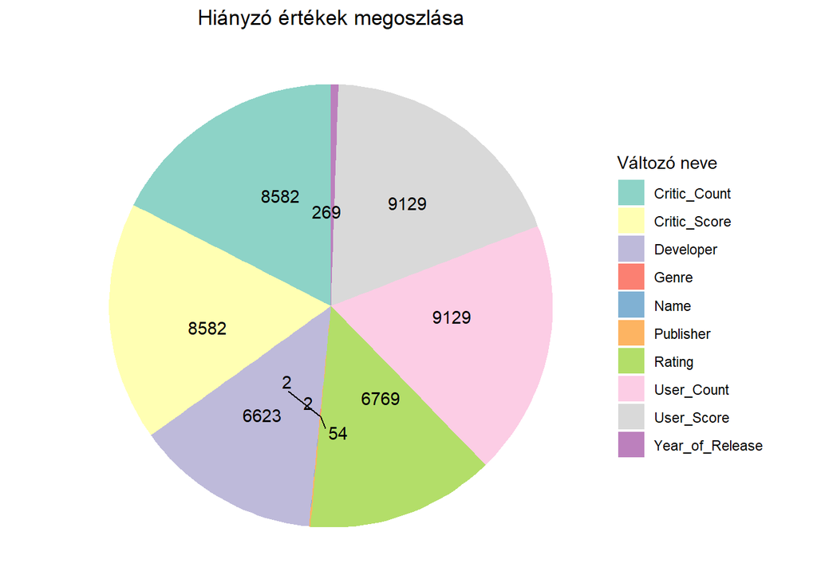

```r
dat %>%
  summarise_all(list(~sum(is.na(.)))) %>%
  gather() %>%
  filter(value!=0) %>%
  ggplot(aes(x=1, y=value, fill=key)) +
  geom_col() +
  ggrepel::geom_text_repel(aes(label=value), position=position_stack(vjust=0.5))+
  coord_polar(theta="y") +
  theme_void()+
  scale_fill_brewer(palette="Set3")+
  labs(fill="Változó neve")+
  ggtitle("Hiányzó értékek megoszlása")+
  theme(plot.title=element_text(hjust=0.5))
```

A kis összecsúszás ellenére, ami

- Name: 2
- Genre: 2
- Publisher: 54

szépen felfedték magukat a hiányzó értékek. Ez, ha nem vagyunk szerencsések, akár az egész táblát lefedheti, vizsgáljuk meg az átfedésüket (valamint ha rájöttünk, hogy van egy random 2020-as játék is benne, szűkítsük le a dátumot a file létrehozásának dátumára)

```r
dat <- filter(dat, year(Year_of_Release)<=2017)

dat %>%
  filter(!complete.cases(.)) %>%
  nrow()
```

```
## [1] 9624
```

Ezzel egyébként a hiányzó dátumú sorok is törlődtek, de mivel ez csak 269 elemet érintett, és szinte minden elemzésem alapja a dátum, így nem probléma.

Látjuk továbbá, hogy szerencsések vagyunk, és “csak” 9624 hiányzó sorunk van. Nem jó de, nem is tragikus. Készítünk belőle egy új, szűrt adathalmazt, és leellenőrizzük, valóban nincs-e további hiányzó érték.

```r
no_NA <- dat[complete.cases(dat), ]

sum(!complete.cases(no_NA))
```

```
## [1] 0
```

### Outlierek vizsgálata

Mielőtt elemzésekbe kezdenénk, a torzítások megelőzése érdekében megvizsgáljuk a kiugró értékeket, vagyis outliereket. Ezt boxplot segítségével tesszük meg.

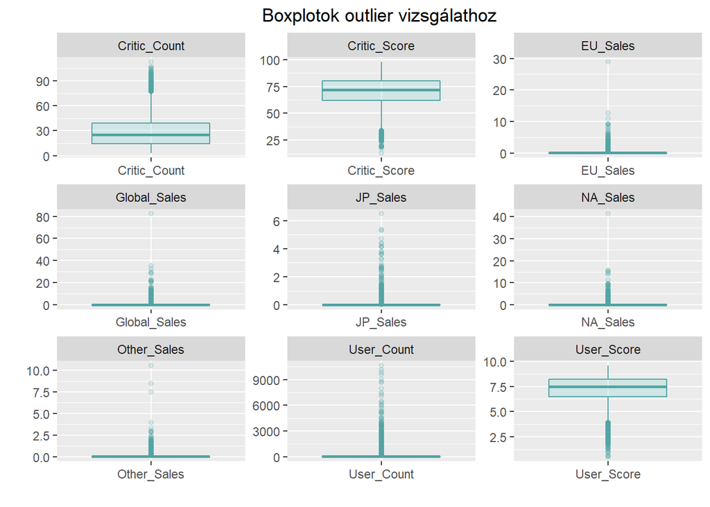

```r
no_NA %>%
  select_if(is.numeric) %>%
  gather() %>%
  ggplot(aes(factor(key), value))+
  geom_boxplot(color="#51a3a3", fill="#66CCCC", alpha=0.2)+
  facet_wrap(~key, scale="free")+
  labs(x="", y="")+
  ggtitle("Boxplotok outlier vizsgálathoz")+
  theme(plot.title=element_text(hjust=0.5))
```

Három eladási darabszám esetén láthatunk egy egész erősen kiugró értéket. Nem tudhatjuk, hogy ez valami hiba, vagy az egyik legérdekesebb tényezője az adatbázisunknak.

```r
cbind(
no_NA %>%
  select(Name, NA_Sales) %>%
  arrange(desc(NA_Sales)) %>%
  top_n(2),

no_NA %>%
  select(Name, EU_Sales) %>%
  arrange(desc(EU_Sales)) %>%
  top_n(2),

no_NA %>%
  select(Name, Global_Sales) %>%
  arrange(desc(Global_Sales)) %>%
  top_n(2))
```

```
##             Name NA_Sales           Name EU_Sales           Name Global_Sales
## 1     Wii Sports    41.36     Wii Sports    28.96     Wii Sports        82.53
## 2 Mario Kart Wii    15.68 Mario Kart Wii    12.76 Mario Kart Wii        35.52
```

Ha mindhárom változónál megnézzük a maximális értékeket, láthatjuk, hogy minden esetben a Wii Sports-hoz tartozik a kiugró érték. És valóban, ennek a játéknak a megjelenése [nagy sikerrel járt](https://www.gamespot.com/articles/the-most-influential-games-of-the-21st-century-wii/1100-6466810/).

### Adatok feltáró elemzése

Kezdjük az elején, nézzük meg a kiadott játékok számának alakulását az idő előrahaladtával.

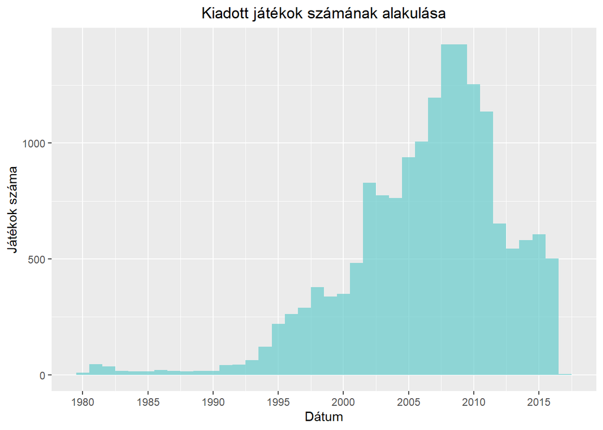

```r
ggplot(dat) +
  geom_bar(aes(year(Year_of_Release)), width=1, fill="#66CCCC", alpha=0.7)+
  labs(x="Dátum", y="Játékok száma")+
  ggtitle("Kiadott játékok számának alakulása")+
  theme(plot.title=element_text(hjust=0.5))+
  scale_x_continuous(breaks = scales::pretty_breaks(10))
```

2009-ig közel exponenciáls ütemű növekedés volt tapasztalható, majd a lendület ennél is gyorsabban esett vissza a 2002-es szintre. Ezt egészen biztos, hogy érdemes tovább boncolgatni.

### Platformok szerinti bontás

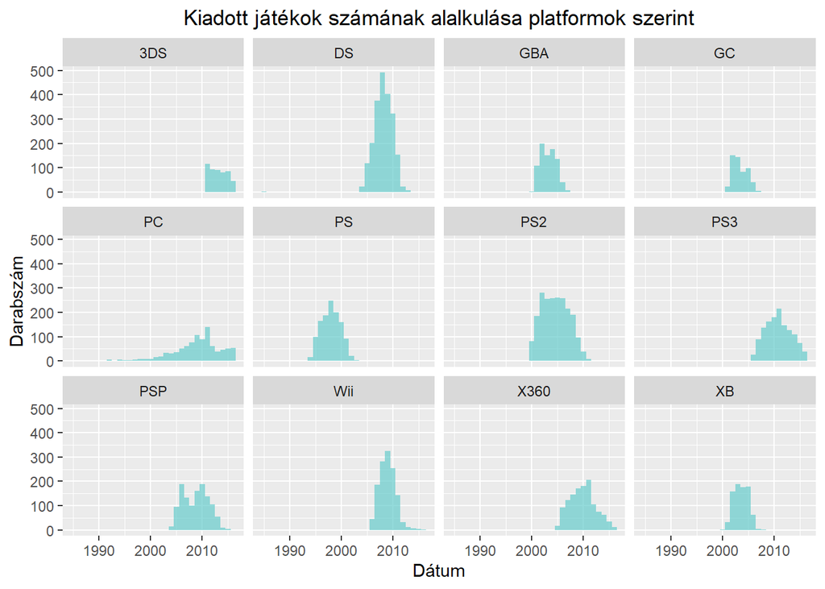

```r
dat %>%
  group_by(Platform) %>%
  filter(n()>500) %>%
  ggplot() +
    geom_bar(aes(year(Year_of_Release)), width=1, fill="#66CCCC", alpha=0.7)+
    labs(x="Dátum", y="Darabszám")+
    ggtitle("Kiadott játékok számának alalkulása platformok szerint")+
    scale_fill_brewer(palette="Set3")+
    theme(plot.title=element_text(hjust=0.5))+
    facet_wrap(.~Platform)
```

Ha megnézzük “legaktívabb” platformonként a játék kiadási számokat, láthatjuk, hogy ezért nagyrészt a Nintendo DS és a Nintendo Wii felel. A DS után pár napra a PSP is megjelent (hasonló stílus ugye), mely szintén hozzájárult a 2009-es csúcshoz.

Pusztán érdekességből megnézhetjük a PlayStation konzolok élettartamát is:

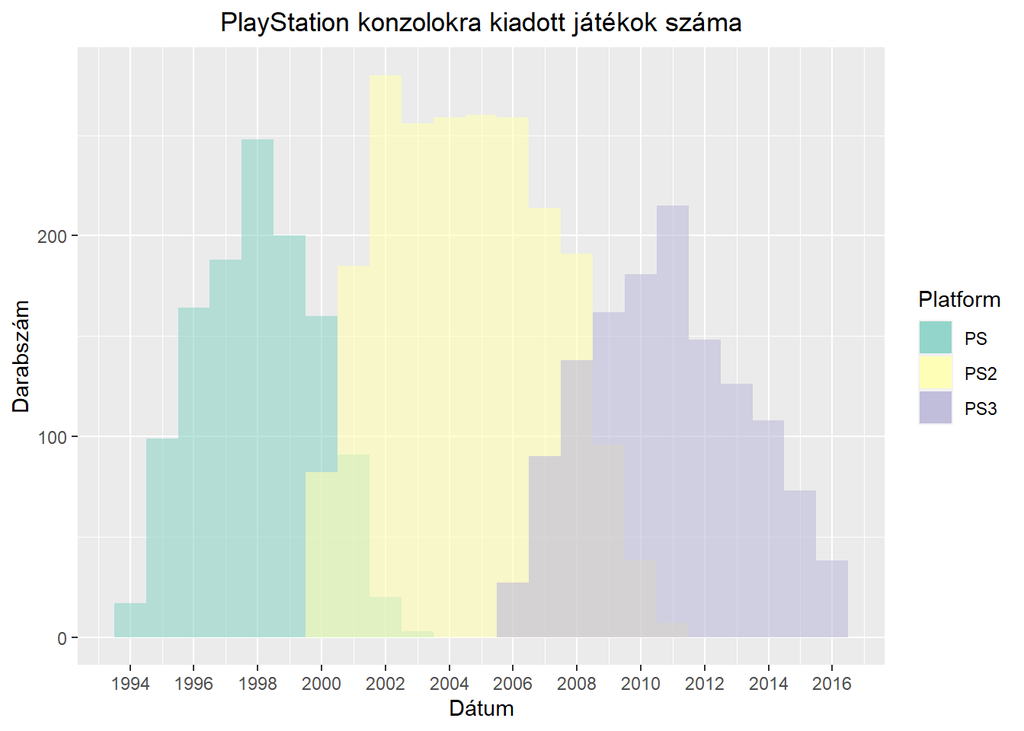

```r
ggplot()+
  geom_bar(data=filter(dat, Platform=="PS"), aes(year(Year_of_Release), fill=Platform), width=1, alpha=0.6)+
  geom_bar(data=filter(dat, Platform=="PS2"), aes(year(Year_of_Release), fill=Platform), width=1, alpha=0.6)+
  geom_bar(data=filter(dat, Platform=="PS3"), aes(year(Year_of_Release), fill=Platform), width=1, alpha=0.6)+
  labs(x="Dátum", y="Darabszám")+
  ggtitle("PlayStation konzolokra kiadott játékok száma")+
  scale_fill_brewer(palette="Set3")+
  theme(plot.title=element_text(hjust=0.5))+
  scale_x_continuous(breaks = scales::pretty_breaks(10))
```

Vizsgáljuk meg a különböző platformokat egyesítve is.

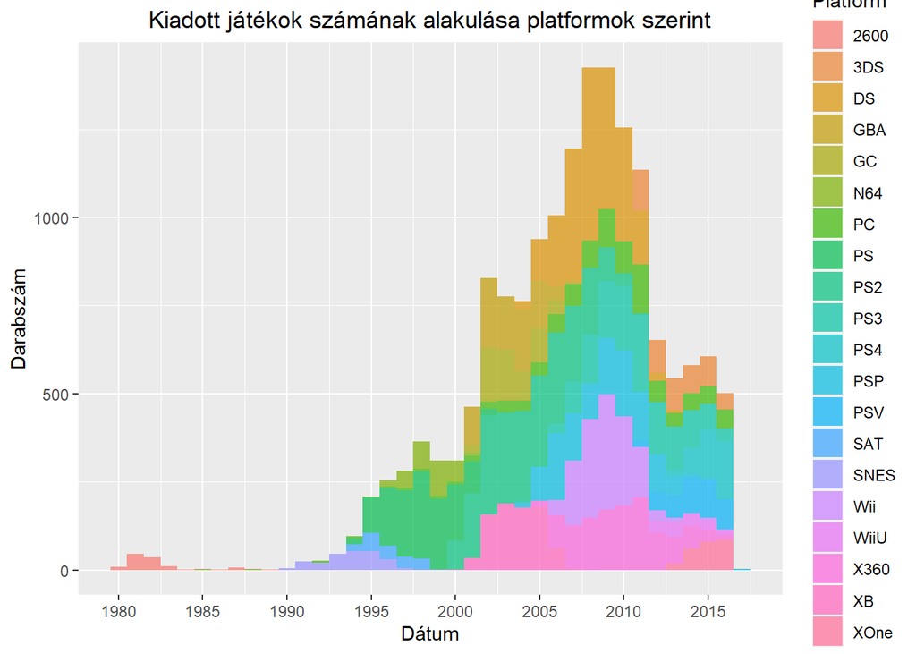

```r
dat %>%
  group_by(Platform) %>%
  filter(n()>100) %>%
  ggplot(aes(fill=Platform)) +
  geom_bar(mapping = aes(year(Year_of_Release)), width=1, alpha=0.7)+
  labs(x="Dátum", y="Darabszám")+
  ggtitle("Kiadott játékok számának alakulása platformok szerint")+
  theme(plot.title=element_text(hjust=0.5))+
  scale_x_continuous(breaks = scales::pretty_breaks(10))
```

Láthatjuk, hogy a csúcs időszakában sokkal nagyobb mértékű felhozatal volt a piacon. Talán mondhatni, hogy az arcade játékok 80-as évek beli aranykora megismétlődött?

### Műfajok szerinti bontás

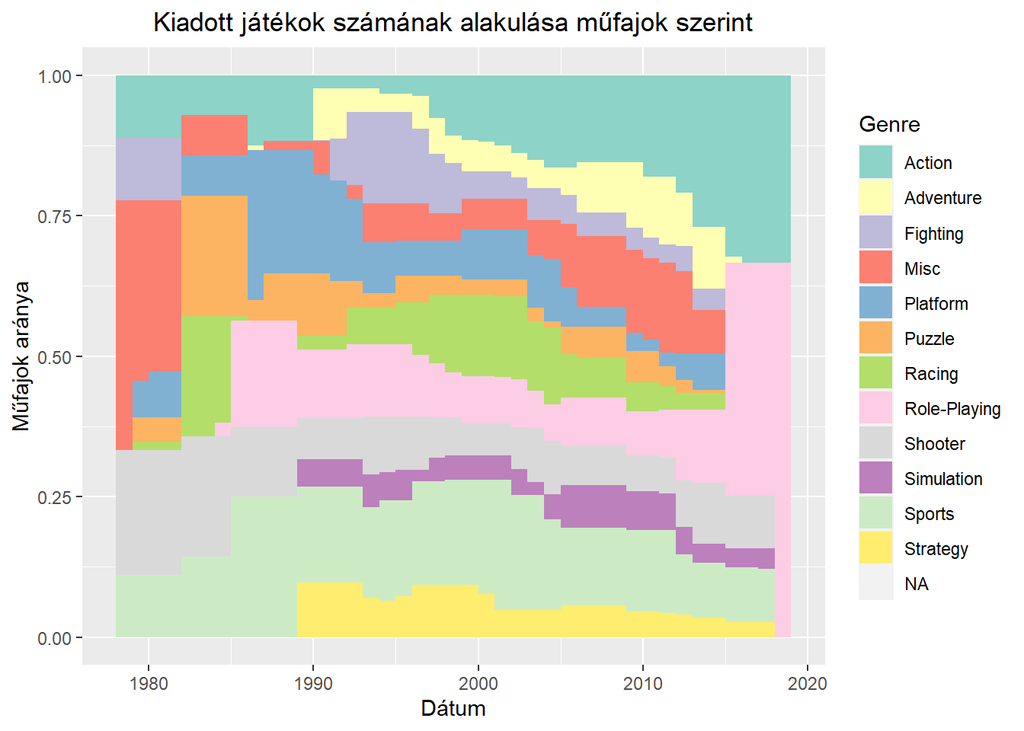

```r
dat %>%
  ggplot(aes(fill=Genre)) +
  geom_bar(position="fill", mapping = aes(year(Year_of_Release)), width=4)+
  labs(x="Dátum", y="Műfajok aránya")+
  scale_fill_brewer(palette="Set3")+
  ggtitle("Kiadott játékok számának alakulása műfajok szerint")+
  theme(plot.title=element_text(hjust=0.5))
```

Ezen a 100%-ig halmozott oszlopdiagramon követni tudjuk az egyes műfajú játékok számának alakulását, megjelenését.

Amit megállapíthatunk róla, hogy az akció játékok kezdik uralni a piac nagy részét, folyamatos emelkedésben van. A Legtöbb műfaj képviselőinek aránya igazából stagnál, a stratégiai, sport, versenyző játékok vannak egyre csökkenő arányban jelen, míg mintha a szerepjátékok újra növekedésnek indultak volna.

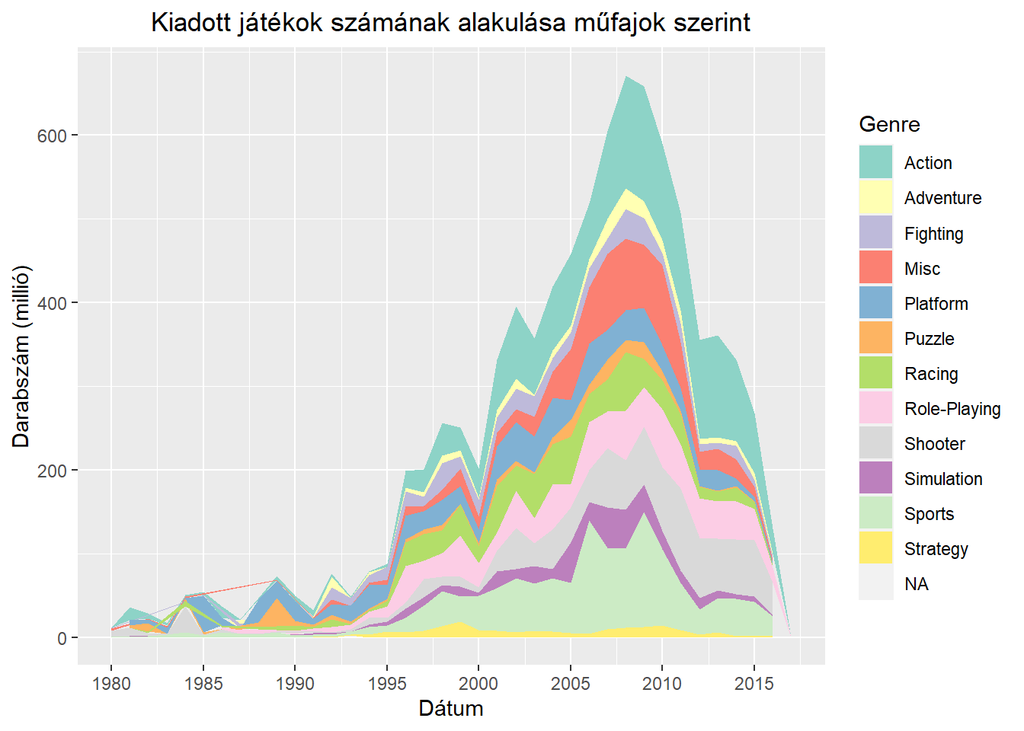

```r
dat %>%
  group_by(Year_of_Release, Genre) %>%
  summarise(Global_Sales=sum(Global_Sales)) %>%
  ggplot(aes(Year_of_Release, Global_Sales, fill=Genre))+
  geom_area()+
  xlab("Dátum")+
  ylab("Darabszám (millió)")+
  ggtitle("Kiadott játékok számának alakulása műfajok szerint")+
  theme(plot.title=element_text(hjust=0.5))+
  scale_fill_brewer(palette="Set3")+
  scale_x_date(breaks = scales::pretty_breaks(10))
```

Hogy ne csak az arányokat lássuk, hanem a mértéküket is megismerjük, hasznos lehet a fenti terület diagram.

### Vélemények elemzése

Nézzük meg, hogyan alakultak a Metacritic felhasználói értékelései az évek alatt, valamint illesszünk rá egy lineáris regressziós trendet.

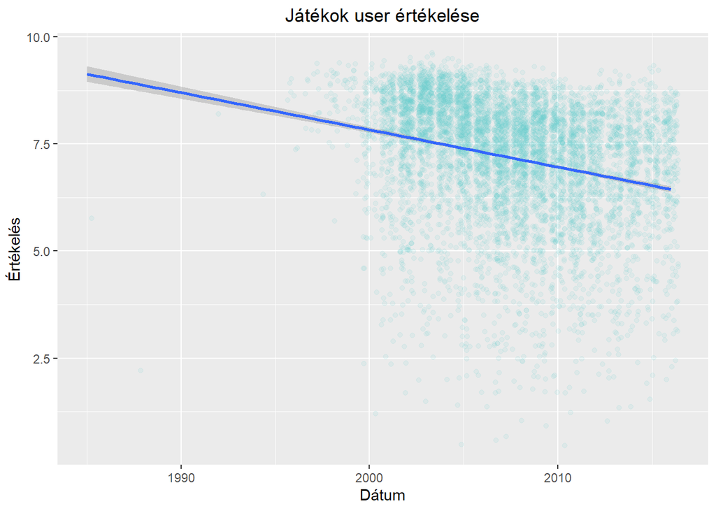

```r
no_NA %>%
  ggplot(aes(Year_of_Release, User_Score))+
  geom_jitter(alpha=0.1, color="#66CCCC")+
  geom_smooth(method="lm")+
  labs(x="Dátum", y="Értékelés")+
  ggtitle("Játékok user értékelése")+
  theme(plot.title=element_text(hjust=0.5))
```

A pontdiagram és a trend alapján is úgy néz ki, csökkenés mutatkozik a játékosok elégedettségét illetően. Ez persze a játékok számának növekedésével, hígulásával is összefüggésben lehet.

Nézzük meg ugyanezt a diagramot a kritikusok véleménye alapján.

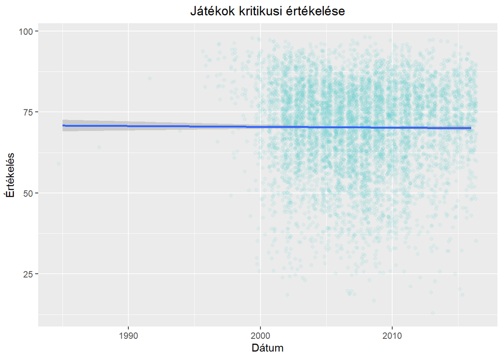

```r
no_NA %>%
  ggplot(aes(Year_of_Release, Critic_Score))+
  geom_jitter(alpha=0.1, color="#66CCCC")+
  geom_smooth(method="lm")+
  labs(x="Dátum", y="Értékelés")+
  ggtitle("Játékok kritikusi értékelése")+
  theme(plot.title=element_text(hjust=0.5))
```

Érdekes módon a kritikusi vélemények átlagos értékelése az évek során jelentősen nem változott.

Ezt kicsit jobban is megvizsgálom:

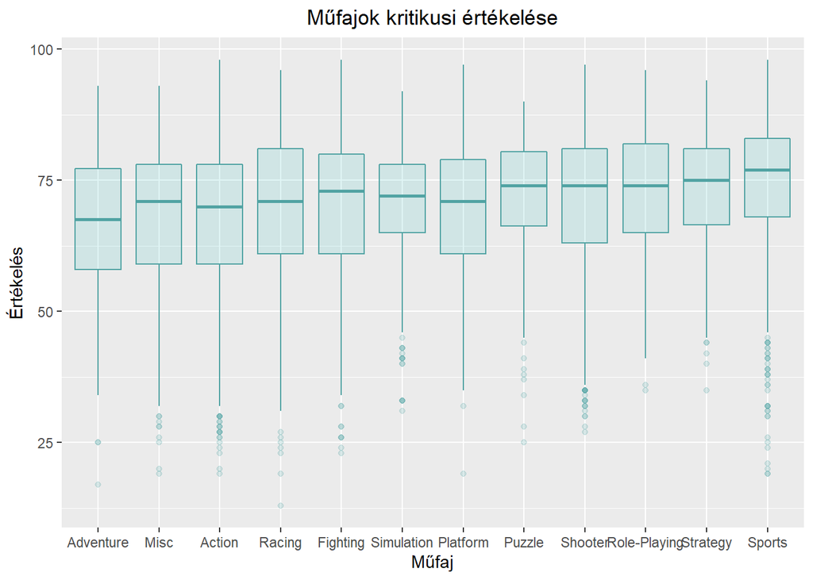

```r
no_NA %>%
  ggplot(aes(reorder(Genre, Critic_Score, function(x) + mean(x)), Critic_Score))+
  geom_boxplot(color="#51a3a3", fill="#66CCCC", alpha=0.2)+
  labs(x="Műfaj", y="Értékelés")+
  ggtitle("Műfajok kritikusi értékelése")+
  theme(plot.title=element_text(hjust=0.5))
```

Láthatjuk, hogy minden kategóriában bőven akadnak lefelé kilógó értékek, és a nagy számban kiadott akció játékok átlagos értékelése bizony a legalacsonyabb értékek egyike, míg a sport és stratégia játékok rendelkeznek a legjobb átlag értékeléssel.

Megnézhetjük, hogyan vélekedtek ezzel szemben a játékosok évről évre.

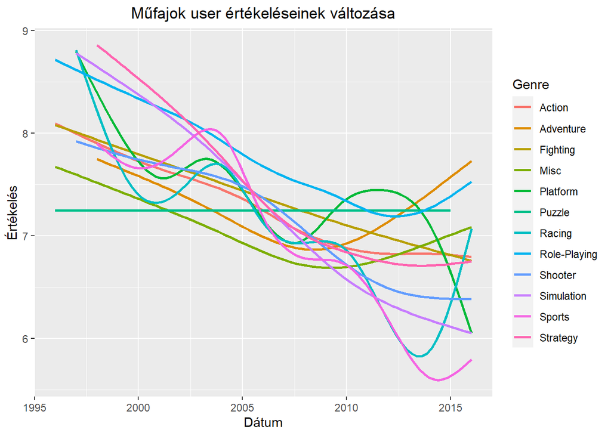

```r
no_NA %>%
  filter(year(Year_of_Release)>1995) %>%
  ggplot(aes(Year_of_Release, User_Score, color=Genre))+
  geom_smooth(se=FALSE)+
  labs(x="Dátum", y="Értékelés")+
  ggtitle("Műfajok user értékeléseinek változása")+
  theme(plot.title=element_text(hjust=0.5))
```

A legtöbb műfaj értékelése romlott idővel, a kalandjátékok, szerepjátékok értékelése javult az utóbbi években.

Most hogy már tudjuk hogyan vélekednek a kritikusok és játékosok a műfajokról, nézzük meg a véleményüket a platformokat illetően.

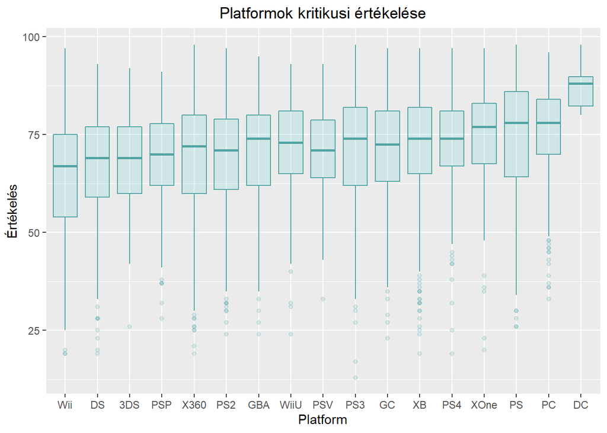

```r
no_NA %>%
  ggplot(aes(reorder(Platform, Critic_Score, function(x) + mean(x)), Critic_Score))+
  geom_boxplot(color="#51a3a3", fill="#66CCCC", alpha=0.2)+
  labs(x="Platform", y="Értékelés")+
  ggtitle("Platformok kritikusi értékelése")+
  theme(plot.title=element_text(hjust=0.5))
```

A Wii játékok hiába voltak nagy számban eladva, a kritikusok mégis a legrosszabb jétékokkal rendelkező platformnak tartják. Magasan a Dreamcast platform játékai kapták a legjobb értékelést, ez a Sega 1998-as konzolja egyébként, és így nézett ki (érdekessége, hogy a kontrolleren is volt egy kis képernyő):

[figure not shown]

A jó értékeléshez persze hozzájárul, hogy jóval kevesebb játékról van szó mint a többi platform esetén, így például a második legjobb játékokkal rendelkező PC talán még nagyobb eredménynek számít.

Érdekes lehet, hogy mennyire találkozik a kritikusok és felhasználók véleménye az egyes platformok esetén.

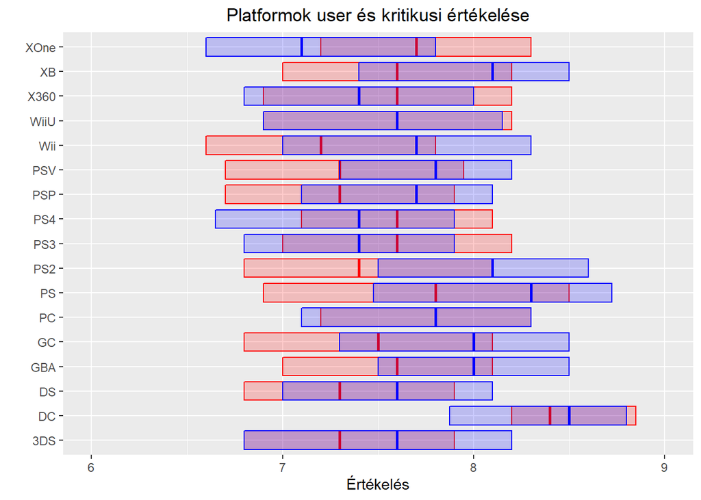

```r
no_NA %>%
  ggplot()+
  geom_boxplot(aes(Platform, Critic_Score/10, ymin=..lower.., ymax=..upper..), fill="red", color="red", alpha=0.2, outlier.size=-1)+
  geom_boxplot(aes(Platform, User_Score, ymin=..lower.., ymax=..upper..), fill="blue", color="blue", alpha=0.2, outlier.size=-1)+
  labs(x="", y="Értékelés")+
  ggtitle("Platformok user és kritikusi értékelése")+
  theme(plot.title=element_text(hjust=0.5))+
  coord_flip()+
  ylim(6,9)
```

Az Xbox One esetében a felhasználók sokkal kevésbé elégedettek a játékokkal, míg az Xbox, Wii, PS Vita, PS2, PS és GameCube platformok esetén a kritikusoknak nyerték el kevésbé a tetszésüket.

### TOP játékok

Nincs más hátra, mint az igazi gigászok vizsgálata, minden év legnagyobb példányszámban eladott játékainak (ami része az adathalmaznak). Tiszteletem jeléül álljon itt a teljes lista:

```r
dat %>%
  group_by(Name) %>%
  group_by(Year_of_Release) %>%
  top_n(1, Global_Sales) %>%
  arrange(Year_of_Release) %>%
  mutate(year = year(Year_of_Release)) %>%
  ungroup() %>%
  select(year, Name, Global_Sales) %>%
  knitr::kable("html", col.names=c("Év", "Játék", "Nemzetközi eladás (millió darab)"), align="c")
```

| Év | Játék | Nemzetközi eladás (millió darab) |
| --- | --- | --- |
| 1980 | Asteroids | 4.31 |
| 1981 | Pitfall! | 4.50 |
| 1982 | Pac-Man | 7.81 |
| 1983 | Baseball | 3.20 |
| 1984 | Duck Hunt | 28.31 |
| 1985 | Super Mario Bros. | 40.24 |
| 1986 | The Legend of Zelda | 6.51 |
| 1987 | Zelda II: The Adventure of Link | 4.38 |
| 1988 | Super Mario Bros. 3 | 17.28 |
| 1989 | Tetris | 30.26 |
| 1990 | Super Mario World | 20.61 |
| 1991 | The Legend of Zelda: A Link to the Past | 4.61 |
| 1992 | Super Mario Land 2: 6 Golden Coins | 11.18 |
| 1993 | Super Mario All-Stars | 10.55 |
| 1994 | Donkey Kong Country | 9.30 |
| 1995 | Donkey Kong Country 2: Diddy’s Kong Quest | 5.15 |
| 1996 | Pokemon Red/Pokemon Blue | 31.37 |
| 1997 | Gran Turismo | 10.95 |
| 1998 | PokĂ©mon Yellow: Special Pikachu Edition | 14.64 |
| 1999 | Pokemon Gold/Pokemon Silver | 23.10 |
| 2000 | PokĂ©mon Crystal Version | 6.39 |
| 2001 | Gran Turismo 3: A-Spec | 14.98 |
| 2002 | Grand Theft Auto: Vice City | 16.15 |
| 2003 | Need for Speed Underground | 7.20 |
| 2004 | Grand Theft Auto: San Andreas | 20.81 |
| 2005 | Nintendogs | 24.67 |
| 2006 | Wii Sports | 82.53 |
| 2007 | Wii Fit | 22.70 |
| 2008 | Mario Kart Wii | 35.52 |
| 2009 | Wii Sports Resort | 32.77 |
| 2010 | Kinect Adventures! | 21.81 |
| 2011 | Call of Duty: Modern Warfare 3 | 14.73 |
| 2012 | Call of Duty: Black Ops II | 13.79 |
| 2013 | Grand Theft Auto V | 21.04 |
| 2014 | Grand Theft Auto V | 12.61 |
| 2015 | Call of Duty: Black Ops 3 | 14.63 |
| 2016 | FIFA 17 | 7.59 |
| 2017 | Phantasy Star Online 2 Episode 4: Deluxe Package | 0.04 |

Ha már nem bogarásszuk a neveket, vizualizáljuk az adataikat. Mondjuk kíváncsiak lehetünk rá, milyen műfajból került ki a legtöbb gigász.

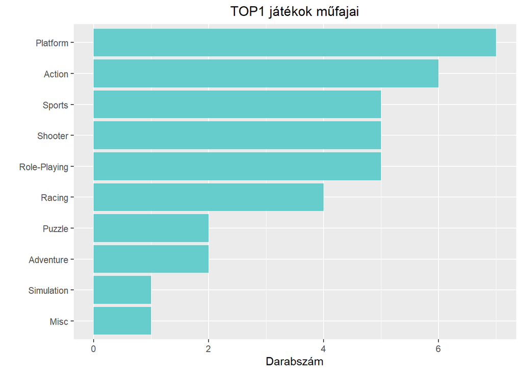

```r
dat %>%
  group_by(Name) %>%
  group_by(Year_of_Release) %>%
  top_n(1, Global_Sales) %>%
  ggplot(aes(reorder(Genre,Genre,function(x)+length(x))))+
  geom_bar(fill="#66CCCC")+
  coord_flip()+
  labs(x="", y="Darabszám")+
  ggtitle("TOP1 játékok műfajai")+
  theme(plot.title=element_text(hjust=0.5))
```

Platform játékok alatt azokat az elsősorban retró játékokat értjük, ahol 2D-ben levő környezetben kell emelvényekről, vagyis platformokról ugrálni és előre (hátra) futni.

Nagy meglepetés nincs a további sorrendben, nem mond ellent a korábban elemzett kedveltségnek.

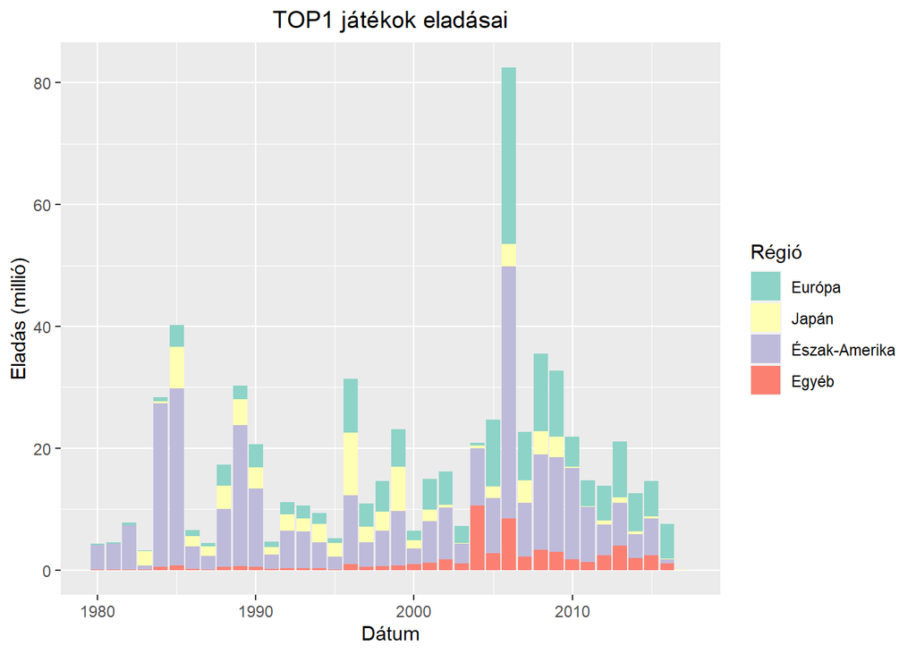

```r
dat %>%
  group_by(Name) %>%
  group_by(Year_of_Release) %>%
  top_n(1, Global_Sales) %>%
  select(Year_of_Release, NA_Sales, EU_Sales, JP_Sales, Other_Sales) %>%
  gather(type, count, -Year_of_Release) %>%
  ggplot(aes(as.Date(Year_of_Release, "%Y"), count, fill=factor(type)))+
  geom_bar(stat="identity")+
  labs(x="Dátum", y="Eladás (millió)", fill="Régió")+
  ggtitle("TOP1 játékok eladásai")+
  theme(plot.title=element_text(hjust=0.5))+
  scale_fill_brewer(palette="Set3", labels=c("Európa", "Japán", "Észak-Amerika", "Egyéb"))
```

Az első diagramon látható, hogy a kétezres évek előtt az átlagos TOP1 játék eladási száma viszonylag alacsonynak mondható, míg vannak kimondottan magas számokkal rendelkező társaik is.

2000 után ez a fajta forma megtört, és egy sokkal kiszámíthatóbban mozgó ábra rajzolódik ki.

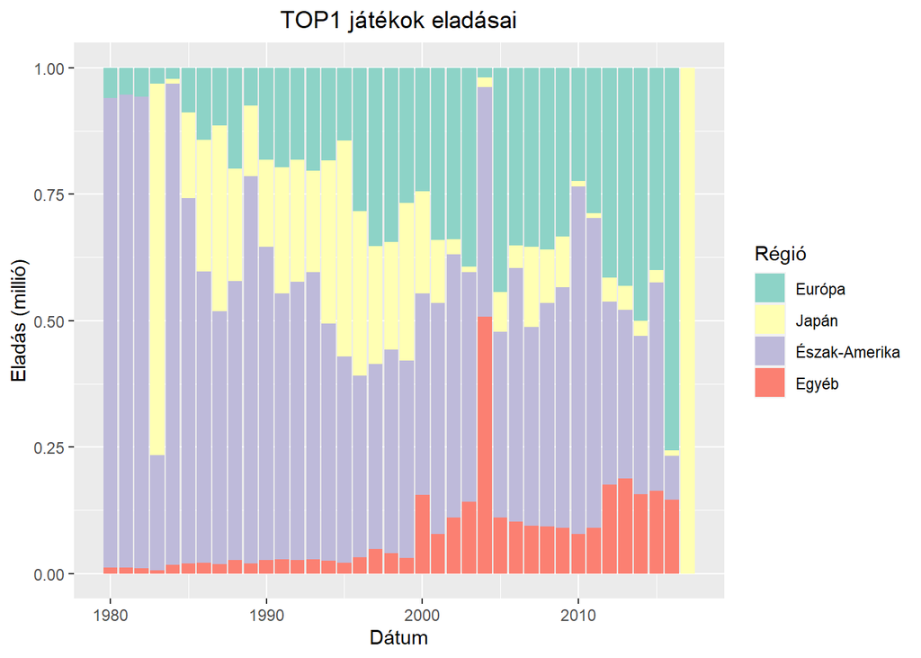

```r
dat %>%
  group_by(Name) %>%
  group_by(Year_of_Release) %>%
  top_n(1, Global_Sales) %>%
  select(Year_of_Release, NA_Sales, EU_Sales, JP_Sales, Other_Sales) %>%
  gather(type, count, -Year_of_Release) %>%
  ggplot(aes(as.Date(Year_of_Release, "%Y"), count, fill=factor(type)))+
  geom_bar(stat="identity", position="fill")+
  labs(x="Dátum", y="Eladás (millió)", fill="Régió")+
  ggtitle("TOP1 játékok eladásai")+
  theme(plot.title=element_text(hjust=0.5))+
  scale_fill_brewer(palette="Set3", labels=c("Európa", "Japán", "Észak-Amerika", "Egyéb"))
```

A második, 100%-ig halmozott ábrán pedig jól megfigyelhető, ahogy Európa felvásárlási ereje egyre jelentősebbé vált, míg Japáné szinte megszűnt. Észak-Amerika viszonylagos stabilitást mutat, az egyéb régiók pedig az ezredforduló után váltak jelentőssé.

Úgy gondolom, elejétől a végéig sikerült kivesézni az adattáblát, és nagyon sok érdekes következtetést tudtunk hozni.

### Köszönöm a figyelmet, remélem aki olvasta érdekesnek találta!